# A1

## Part 1: Data scraping and preparation

### Step 1: Scrape your competitor's data

```python
# Get necessary Python packages
import requests
from bs4 import BeautifulSoup
import pandas as pd
import numpy as np
```

```python
# Read from SpaceWeatherLive.com
headers = {
    'User-Agent': 'Mozilla/5.0 (Windows NT 10.0; Win64; x64) AppleWebKit/537.36 (KHTML, like Gecko) Chrome/110.0.0.0 Safari/537.36',
    'From': 'pleaseletmein@gmail.com'
}

r = requests.get("https://www.spaceweatherlive.com/en/solar-activity/top-50-solar-flares", headers=headers)

# Check status code
if r.status_code != 200:
  print("Request failed from the provided website.")
else:
  # Extract the text from the page
  content = r.text

# Use BeautifulSoup to read and parse the data as HTML
root = BeautifulSoup(content, 'html.parser')

# View the content and find the appropriate table
# print(root.prettify())
root.prettify()

# Use find() to save the aforementioned table as a variable
table = root.find('table')

# Use pandas to read in the HTML file.
df = pd.read_html(str(table))
# create data frame from list
df = pd.concat(df)

print(f"Dimension: {df.shape[0]} x {df.shape[1]} \n")
df.columns = ['rank', 'x_class', 'date', 'region', 'start_time', 'max_time', 'end_time', 'movie']
df.index = df.index + 1
df
```

```
Dimension: 50 x 8
```

|  | rank | x_class | date | region | start_time | max_time | end_time | movie |
| --- | --- | --- | --- | --- | --- | --- | --- | --- |
| 1 | 1 | X28+ | 2003/11/04 | 486 | 19:29 | 19:53 | 20:06 | MovieView archive |
| 2 | 2 | X20+ | 2001/04/02 | 9393 | 21:32 | 21:51 | 22:03 | MovieView archive |
| 3 | 3 | X17.2+ | 2003/10/28 | 486 | 09:51 | 11:10 | 11:24 | MovieView archive |
| 4 | 4 | X17+ | 2005/09/07 | 808 | 17:17 | 17:40 | 18:03 | MovieView archive |
| 5 | 5 | X14.4 | 2001/04/15 | 9415 | 13:19 | 13:50 | 13:55 | MovieView archive |
| 6 | 6 | X10 | 2003/10/29 | 486 | 20:37 | 20:49 | 21:01 | MovieView archive |
| 7 | 7 | X9.4 | 1997/11/06 | 8100 | 11:49 | 11:55 | 12:01 | MovieView archive |
| 8 | 8 | X9.3 | 2017/09/06 | 2673 | 11:53 | 12:02 | 12:10 | MovieView archive |
| 9 | 9 | X9 | 2006/12/05 | 930 | 10:18 | 10:35 | 10:45 | MovieView archive |
| 10 | 10 | X8.3 | 2003/11/02 | 486 | 17:03 | 17:25 | 17:39 | MovieView archive |
| 11 | 11 | X8.2 | 2017/09/10 | 2673 | 15:35 | 16:06 | 16:31 | MovieView archive |
| 12 | 12 | X7.1 | 2005/01/20 | 720 | 06:36 | 07:01 | 07:26 | MovieView archive |
| 13 | 13 | X6.9 | 2011/08/09 | 1263 | 07:48 | 08:05 | 08:08 | MovieView archive |
| 14 | 14 | X6.5 | 2006/12/06 | 930 | 18:29 | 18:47 | 19:00 | MovieView archive |
| 15 | 15 | X6.2 | 2005/09/09 | 808 | 19:13 | 20:04 | 20:36 | MovieView archive |
| 16 | 16 | X6.2 | 2001/12/13 | 9733 | 14:20 | 14:30 | 14:35 | MovieView archive |
| 17 | 17 | X5.7 | 2000/07/14 | 9077 | 10:03 | 10:24 | 10:43 | MovieView archive |
| 18 | 18 | X5.6 | 2001/04/06 | 9415 | 19:10 | 19:21 | 19:31 | MovieView archive |
| 19 | 19 | X5.4 | 2012/03/07 | 1429 | 00:02 | 00:24 | 00:40 | MovieView archive |
| 20 | 20 | X5.4 | 2005/09/08 | 808 | 20:52 | 21:06 | 21:17 | MovieView archive |
| 21 | 21 | X5.4 | 2003/10/23 | 486 | 08:19 | 08:35 | 08:49 | MovieView archive |
| 22 | 22 | X5.3 | 2001/08/25 | 9591 | 16:23 | 16:45 | 17:04 | MovieView archive |
| 23 | 23 | X4.9 | 2014/02/25 | 1990 | 00:39 | 00:49 | 01:03 | MovieView archive |
| 24 | 24 | X4.9 | 1998/08/18 | 8307 | 22:10 | 22:19 | 22:28 | View archive |
| 25 | 25 | X4.8 | 2002/07/23 | 39 | 00:18 | 00:35 | 00:47 | MovieView archive |
| 26 | 26 | X4 | 2000/11/26 | 9236 | 16:34 | 16:48 | 16:56 | MovieView archive |
| 27 | 27 | X3.9 | 2003/11/03 | 488 | 09:43 | 09:55 | 10:19 | MovieView archive |
| 28 | 28 | X3.9 | 1998/08/19 | 8307 | 21:35 | 21:45 | 21:50 | View archive |
| 29 | 29 | X3.8 | 2005/01/17 | 720 | 06:59 | 09:52 | 10:07 | MovieView archive |
| 30 | 30 | X3.7 | 1998/11/22 | 8384 | 06:30 | 06:42 | 06:49 | MovieView archive |
| 31 | 31 | X3.6 | 2005/09/09 | 808 | 09:42 | 09:59 | 10:08 | MovieView archive |
| 32 | 32 | X3.6 | 2004/07/16 | 649 | 13:49 | 13:55 | 14:01 | MovieView archive |
| 33 | 33 | X3.6 | 2003/05/28 | 365 | 00:17 | 00:27 | 00:39 | MovieView archive |
| 34 | 34 | X3.4 | 2006/12/13 | 930 | 02:14 | 02:40 | 02:57 | MovieView archive |
| 35 | 35 | X3.4 | 2001/12/28 | 9767 | 20:02 | 20:45 | 21:32 | MovieView archive |
| 36 | 36 | X3.3 | 2013/11/05 | 1890 | 22:07 | 22:12 | 22:15 | MovieView archive |
| 37 | 37 | X3.3 | 2002/07/20 | 39 | 21:04 | 21:30 | 21:54 | MovieView archive |
| 38 | 38 | X3.3 | 1998/11/28 | 8395 | 04:54 | 05:52 | 06:13 | MovieView archive |
| 39 | 39 | X3.2 | 2013/05/14 | 1748 | 00:00 | 01:11 | 01:20 | MovieView archive |
| 40 | 40 | X3.1 | 2014/10/24 | 2192 | 21:07 | 21:41 | 22:13 | MovieView archive |
| 41 | 41 | X3.1 | 2002/08/24 | 69 | 00:49 | 01:12 | 01:31 | MovieView archive |
| 42 | 42 | X3 | 2002/07/15 | 30 | 19:59 | 20:08 | 20:14 | MovieView archive |
| 43 | 43 | X2.8 | 2013/05/13 | 1748 | 15:48 | 16:05 | 16:16 | MovieView archive |
| 44 | 44 | X2.8 | 2001/12/11 | 9733 | 07:58 | 08:08 | 08:14 | MovieView archive |
| 45 | 45 | X2.8 | 1998/08/18 | 8307 | 08:14 | 08:24 | 08:32 | View archive |
| 46 | 46 | X2.7 | 2015/05/05 | 2339 | 22:05 | 22:11 | 22:15 | MovieView archive |
| 47 | 47 | X2.7 | 2003/11/03 | 488 | 01:09 | 01:30 | 01:45 | MovieView archive |
| 48 | 48 | X2.7 | 1998/05/06 | 8210 | 07:58 | 08:09 | 08:20 | MovieView archive |
| 49 | 49 | X2.6 | 2005/01/15 | 720 | 22:25 | 23:02 | 23:31 | MovieView archive |
| 50 | 50 | X2.6 | 2001/09/24 | 9632 | 09:32 | 10:38 | 11:09 | MovieView archive |

### Step 2: Tidy the top 50 solar flare data

```python
# Drop the last column of the table
df = df.drop(df.columns[-1], axis = 1).copy()

# Use datetime import to combine the date and each of the three time columns into three datetime columns.
for index, row in df.iterrows():
  start_datetime = row['date'] + ' ' + row['start_time']
  max_datetime = row['date'] + ' ' + row['max_time']
  end_datetime = row['date'] + ' ' + row['end_time']

  # Update the values in the dataframe
  df.at[index, 'start_datetime'] = pd.to_datetime(start_datetime)
  df.at[index, 'max_datetime'] = pd.to_datetime(max_datetime)
  df.at[index, 'end_datetime'] = pd.to_datetime(end_datetime)

# Drop the extra columns.
df = df.drop(['date', 'start_time', 'max_time', 'end_time'], axis = 1)

# Set regions coded as - as missing (NaN).
# After verifying the data, no missing values were found. However, the following code will still work as expected.
df["region"] = df["region"].replace('-', np.nan)

# Change the order of columns
df = df[['rank','x_class','start_datetime','max_datetime','end_datetime','region']]

print(f"A Dimension: {df.shape[0]} x {df.shape[1]} \n")
space_weather_top = df.head(50).copy()
df
```

```
A Dimension: 50 x 6
```

|  | rank | x_class | start_datetime | max_datetime | end_datetime | region |
| --- | --- | --- | --- | --- | --- | --- |
| 1 | 1 | X28+ | 2003-11-04 19:29:00 | 2003-11-04 19:53:00 | 2003-11-04 20:06:00 | 486 |
| 2 | 2 | X20+ | 2001-04-02 21:32:00 | 2001-04-02 21:51:00 | 2001-04-02 22:03:00 | 9393 |
| 3 | 3 | X17.2+ | 2003-10-28 09:51:00 | 2003-10-28 11:10:00 | 2003-10-28 11:24:00 | 486 |
| 4 | 4 | X17+ | 2005-09-07 17:17:00 | 2005-09-07 17:40:00 | 2005-09-07 18:03:00 | 808 |
| 5 | 5 | X14.4 | 2001-04-15 13:19:00 | 2001-04-15 13:50:00 | 2001-04-15 13:55:00 | 9415 |
| 6 | 6 | X10 | 2003-10-29 20:37:00 | 2003-10-29 20:49:00 | 2003-10-29 21:01:00 | 486 |
| 7 | 7 | X9.4 | 1997-11-06 11:49:00 | 1997-11-06 11:55:00 | 1997-11-06 12:01:00 | 8100 |
| 8 | 8 | X9.3 | 2017-09-06 11:53:00 | 2017-09-06 12:02:00 | 2017-09-06 12:10:00 | 2673 |
| 9 | 9 | X9 | 2006-12-05 10:18:00 | 2006-12-05 10:35:00 | 2006-12-05 10:45:00 | 930 |
| 10 | 10 | X8.3 | 2003-11-02 17:03:00 | 2003-11-02 17:25:00 | 2003-11-02 17:39:00 | 486 |
| 11 | 11 | X8.2 | 2017-09-10 15:35:00 | 2017-09-10 16:06:00 | 2017-09-10 16:31:00 | 2673 |
| 12 | 12 | X7.1 | 2005-01-20 06:36:00 | 2005-01-20 07:01:00 | 2005-01-20 07:26:00 | 720 |
| 13 | 13 | X6.9 | 2011-08-09 07:48:00 | 2011-08-09 08:05:00 | 2011-08-09 08:08:00 | 1263 |
| 14 | 14 | X6.5 | 2006-12-06 18:29:00 | 2006-12-06 18:47:00 | 2006-12-06 19:00:00 | 930 |
| 15 | 15 | X6.2 | 2005-09-09 19:13:00 | 2005-09-09 20:04:00 | 2005-09-09 20:36:00 | 808 |
| 16 | 16 | X6.2 | 2001-12-13 14:20:00 | 2001-12-13 14:30:00 | 2001-12-13 14:35:00 | 9733 |
| 17 | 17 | X5.7 | 2000-07-14 10:03:00 | 2000-07-14 10:24:00 | 2000-07-14 10:43:00 | 9077 |
| 18 | 18 | X5.6 | 2001-04-06 19:10:00 | 2001-04-06 19:21:00 | 2001-04-06 19:31:00 | 9415 |
| 19 | 19 | X5.4 | 2012-03-07 00:02:00 | 2012-03-07 00:24:00 | 2012-03-07 00:40:00 | 1429 |
| 20 | 20 | X5.4 | 2005-09-08 20:52:00 | 2005-09-08 21:06:00 | 2005-09-08 21:17:00 | 808 |
| 21 | 21 | X5.4 | 2003-10-23 08:19:00 | 2003-10-23 08:35:00 | 2003-10-23 08:49:00 | 486 |
| 22 | 22 | X5.3 | 2001-08-25 16:23:00 | 2001-08-25 16:45:00 | 2001-08-25 17:04:00 | 9591 |
| 23 | 23 | X4.9 | 2014-02-25 00:39:00 | 2014-02-25 00:49:00 | 2014-02-25 01:03:00 | 1990 |
| 24 | 24 | X4.9 | 1998-08-18 22:10:00 | 1998-08-18 22:19:00 | 1998-08-18 22:28:00 | 8307 |
| 25 | 25 | X4.8 | 2002-07-23 00:18:00 | 2002-07-23 00:35:00 | 2002-07-23 00:47:00 | 39 |
| 26 | 26 | X4 | 2000-11-26 16:34:00 | 2000-11-26 16:48:00 | 2000-11-26 16:56:00 | 9236 |
| 27 | 27 | X3.9 | 2003-11-03 09:43:00 | 2003-11-03 09:55:00 | 2003-11-03 10:19:00 | 488 |
| 28 | 28 | X3.9 | 1998-08-19 21:35:00 | 1998-08-19 21:45:00 | 1998-08-19 21:50:00 | 8307 |
| 29 | 29 | X3.8 | 2005-01-17 06:59:00 | 2005-01-17 09:52:00 | 2005-01-17 10:07:00 | 720 |
| 30 | 30 | X3.7 | 1998-11-22 06:30:00 | 1998-11-22 06:42:00 | 1998-11-22 06:49:00 | 8384 |
| 31 | 31 | X3.6 | 2005-09-09 09:42:00 | 2005-09-09 09:59:00 | 2005-09-09 10:08:00 | 808 |
| 32 | 32 | X3.6 | 2004-07-16 13:49:00 | 2004-07-16 13:55:00 | 2004-07-16 14:01:00 | 649 |
| 33 | 33 | X3.6 | 2003-05-28 00:17:00 | 2003-05-28 00:27:00 | 2003-05-28 00:39:00 | 365 |
| 34 | 34 | X3.4 | 2006-12-13 02:14:00 | 2006-12-13 02:40:00 | 2006-12-13 02:57:00 | 930 |
| 35 | 35 | X3.4 | 2001-12-28 20:02:00 | 2001-12-28 20:45:00 | 2001-12-28 21:32:00 | 9767 |
| 36 | 36 | X3.3 | 2013-11-05 22:07:00 | 2013-11-05 22:12:00 | 2013-11-05 22:15:00 | 1890 |
| 37 | 37 | X3.3 | 2002-07-20 21:04:00 | 2002-07-20 21:30:00 | 2002-07-20 21:54:00 | 39 |
| 38 | 38 | X3.3 | 1998-11-28 04:54:00 | 1998-11-28 05:52:00 | 1998-11-28 06:13:00 | 8395 |
| 39 | 39 | X3.2 | 2013-05-14 00:00:00 | 2013-05-14 01:11:00 | 2013-05-14 01:20:00 | 1748 |
| 40 | 40 | X3.1 | 2014-10-24 21:07:00 | 2014-10-24 21:41:00 | 2014-10-24 22:13:00 | 2192 |
| 41 | 41 | X3.1 | 2002-08-24 00:49:00 | 2002-08-24 01:12:00 | 2002-08-24 01:31:00 | 69 |
| 42 | 42 | X3 | 2002-07-15 19:59:00 | 2002-07-15 20:08:00 | 2002-07-15 20:14:00 | 30 |
| 43 | 43 | X2.8 | 2013-05-13 15:48:00 | 2013-05-13 16:05:00 | 2013-05-13 16:16:00 | 1748 |
| 44 | 44 | X2.8 | 2001-12-11 07:58:00 | 2001-12-11 08:08:00 | 2001-12-11 08:14:00 | 9733 |
| 45 | 45 | X2.8 | 1998-08-18 08:14:00 | 1998-08-18 08:24:00 | 1998-08-18 08:32:00 | 8307 |
| 46 | 46 | X2.7 | 2015-05-05 22:05:00 | 2015-05-05 22:11:00 | 2015-05-05 22:15:00 | 2339 |
| 47 | 47 | X2.7 | 2003-11-03 01:09:00 | 2003-11-03 01:30:00 | 2003-11-03 01:45:00 | 488 |
| 48 | 48 | X2.7 | 1998-05-06 07:58:00 | 1998-05-06 08:09:00 | 1998-05-06 08:20:00 | 8210 |
| 49 | 49 | X2.6 | 2005-01-15 22:25:00 | 2005-01-15 23:02:00 | 2005-01-15 23:31:00 | 720 |
| 50 | 50 | X2.6 | 2001-09-24 09:32:00 | 2001-09-24 10:38:00 | 2001-09-24 11:09:00 | 9632 |

### Step 3: Scrape the NASA data

```python
# Read from NASA
r = requests.get("http://cdaw.gsfc.nasa.gov/CME_list/radio/waves_type2.html")

# Check status code
if r.status_code != 200:
  print("Request failed from the provided website.")
else:
  # Extract the text from the page
  content = r.text

# Use BeautifulSoup to read and parse the data as HTML
root = BeautifulSoup(content, 'html.parser')

# View the content and find the appropriate table
# print(root.prettify())
root.prettify()

# Data are in the HTML tag of <pre>, store it as the text
data = root.find('pre').text

# Remove all description sentences using slice, lines are splited by newline character
# to obtain each row of data as a long string.
data = data.split('\n')[12:-2]

# create data frame from list
df = pd.DataFrame(data)

# As each row of data are stored in ID of 0 as a long string,
# we need to split that String column into multiple columns
df = df[0].str.split(expand = True)

# Drop comments at the end
cols = [15,16,17,18,19,20,21,22,23]
df = df.drop(df.columns[cols], axis = 1)

print(f"Dimension: {df.shape[0]} x {df.shape[1]} \n")
df.columns = ['start_date', 'start_time', 'end_date', 'end_time', 'start_frequency', 'end_frequency', \
              'flare_location', 'flare_region', 'importance', 'cme_date', 'cme_time', 'cpa', 'width', 'speed', 'plot']
df.index = df.index + 1
df
```

```
Dimension: 522 x 15
```

|  | start_date | start_time | end_date | end_time | start_frequency | end_frequency | flare_location | flare_region | importance | cme_date | cme_time | cpa | width | speed | plot |
| --- | --- | --- | --- | --- | --- | --- | --- | --- | --- | --- | --- | --- | --- | --- | --- |
| 1 | 1997/04/01 | 14:00 | 04/01 | 14:15 | 8000 | 4000 | S25E16 | 8026 | M1.3 | 04/01 | 15:18 | 74 | 79 | 312 | PHTX |
| 2 | 1997/04/07 | 14:30 | 04/07 | 17:30 | 11000 | 1000 | S28E19 | 8027 | C6.8 | 04/07 | 14:27 | Halo | 360 | 878 | PHTX |
| 3 | 1997/05/12 | 05:15 | 05/14 | 16:00 | 12000 | 80 | N21W08 | 8038 | C1.3 | 05/12 | 05:30 | Halo | 360 | 464 | PHTX |
| 4 | 1997/05/21 | 20:20 | 05/21 | 22:00 | 5000 | 500 | N05W12 | 8040 | M1.3 | 05/21 | 21:00 | 263 | 165 | 296 | PHTX |
| 5 | 1997/09/23 | 21:53 | 09/23 | 22:16 | 6000 | 2000 | S29E25 | 8088 | C1.4 | 09/23 | 22:02 | 133 | 155 | 712 | PHTX |
| ... | ... | ... | ... | ... | ... | ... | ... | ... | ... | ... | ... | ... | ... | ... | ... |
| 518 | 2017/09/17 | 11:45 | 09/17 | 12:35 | 16000 | 900 | S08E170 | ----- | ---- | 09/17 | 12:00 | Halo | 360 | 1385 | PHTX |
| 519 | 2017/10/18 | 05:48 | 10/18 | 12:40 | 16000 | 400 | S06E123 | ----- | ---- | 10/18 | 08:00 | 85 | 146 | 1001 | PHTX |
| 520 | 2019/05/03 | 23:52 | 05/04 | 00:16 | 13000 | 2300 | N12E82 | 12740 | C1.0 | 05/03 | 23:24 | 90 | 113 | 692 | PHTX |
| 521 | 2020/11/29 | 13:07 | 11/29 | 15:23 | 14000 | 850 | S23E89 | ----- | M4.4 | 11/29 | 13:25 | Halo | 360 | 2077 | ---- |
| 522 | 2020/12/07 | 16:18 | 12/08 | 02:00 | 14000 | 160 | S25W08 | 12790 | C7.4 | 12/07 | 16:24 | Halo | 360 | 1407 | ---- |

522 rows × 15 columns

### Step 4: Tidy the NASA table

```python
import re

df = df.copy()
# Recode any missing entries as NaN
df.replace(['????','-----','---','------','BACK','Back','Back?', \
            'FILA','DSF','altr','----','--/--','--:--'], np.nan, inplace = True)

# Create a new column that indicates if a row corresponds to a halo flare or not,
# and then replace Halo entries in the cme_angle column as NA.
df['is_halo'] = np.where(df['cpa']=='Halo', True, False)
df['cpa'] = df['cpa'].replace('Halo', 'NA')

# Create a new column that indicates if width is given as a lower bound,
# and remove any non-numeric part of the width column.
df['width_lower_bound'] = df['width'].str.startswith('>',na=False)
df['width'] = df['width'].str.replace('>','')

# Combine date and time columns for start, end and cme so they can be encoded as datetime objects.
for index, row in df.iterrows():

  start_datetime = row['start_date'] + ' ' + row['start_time']
  year = start_datetime.split('/')[0]
  # Update the values in the dataframe
  df.at[index, 'start_datetime'] = pd.to_datetime(start_datetime)

  # Pay attention to end_datetime as time format are different
  if row['end_time'] == '24:00':
    # Fix time format unmatch error 24:00 -> 00:00
    row['end_time'] = row['end_time'].replace('24:00', '00:00')
    end_datetime = year + '/' + row['end_date'] + ' ' + row['end_time']
    # Update the values in the dataframe
    # after check all datas, we can directly add 1 to dates, there are no special cases
    df.at[index, 'end_datetime'] = pd.to_datetime(end_datetime) + pd.to_timedelta(1, unit='D')
  else:
    end_datetime = year + '/' + row['end_date'] + ' ' + row['end_time']
    # Update the values in the dataframe
    df.at[index, 'end_datetime'] = pd.to_datetime(end_datetime)

  # Pay attention to cme_datetime as they might be empty
  if row['cme_date'] is not np.nan and row['cme_time'] is not np.nan:
    cme_datetime = year + '/' + row['cme_date'] + ' ' + row['cme_time']
    # Update the values in the dataframe
    df.at[index, 'cme_datetime'] = pd.to_datetime(cme_datetime)

# Drop the extra columns.
df = df.drop(['start_date', 'start_time', 'end_date', 'end_time', 'cme_date', 'cme_time'], axis = 1)

# Change the order of columns
df = df[['start_datetime', 'end_datetime', 'start_frequency', 'end_frequency', 'flare_location', \
          'flare_region', 'importance', 'cme_datetime', 'cpa', 'width', 'speed', 'plot', 'is_halo', 'width_lower_bound']]

nasa = df.copy()
df
```

|  | start_datetime | end_datetime | start_frequency | end_frequency | flare_location | flare_region | importance | cme_datetime | cpa | width | speed | plot | is_halo | width_lower_bound |
| --- | --- | --- | --- | --- | --- | --- | --- | --- | --- | --- | --- | --- | --- | --- |
| 1 | 1997-04-01 14:00:00 | 1997-04-01 14:15:00 | 8000 | 4000 | S25E16 | 8026 | M1.3 | 1997-04-01 15:18:00 | 74 | 79 | 312 | PHTX | False | False |
| 2 | 1997-04-07 14:30:00 | 1997-04-07 17:30:00 | 11000 | 1000 | S28E19 | 8027 | C6.8 | 1997-04-07 14:27:00 | NA | 360 | 878 | PHTX | True | False |
| 3 | 1997-05-12 05:15:00 | 1997-05-14 16:00:00 | 12000 | 80 | N21W08 | 8038 | C1.3 | 1997-05-12 05:30:00 | NA | 360 | 464 | PHTX | True | False |
| 4 | 1997-05-21 20:20:00 | 1997-05-21 22:00:00 | 5000 | 500 | N05W12 | 8040 | M1.3 | 1997-05-21 21:00:00 | 263 | 165 | 296 | PHTX | False | False |
| 5 | 1997-09-23 21:53:00 | 1997-09-23 22:16:00 | 6000 | 2000 | S29E25 | 8088 | C1.4 | 1997-09-23 22:02:00 | 133 | 155 | 712 | PHTX | False | False |
| ... | ... | ... | ... | ... | ... | ... | ... | ... | ... | ... | ... | ... | ... | ... |
| 518 | 2017-09-17 11:45:00 | 2017-09-17 12:35:00 | 16000 | 900 | S08E170 | NaN | NaN | 2017-09-17 12:00:00 | NA | 360 | 1385 | PHTX | True | False |
| 519 | 2017-10-18 05:48:00 | 2017-10-18 12:40:00 | 16000 | 400 | S06E123 | NaN | NaN | 2017-10-18 08:00:00 | 85 | 146 | 1001 | PHTX | False | False |
| 520 | 2019-05-03 23:52:00 | 2019-05-04 00:16:00 | 13000 | 2300 | N12E82 | 12740 | C1.0 | 2019-05-03 23:24:00 | 90 | 113 | 692 | PHTX | False | False |
| 521 | 2020-11-29 13:07:00 | 2020-11-29 15:23:00 | 14000 | 850 | S23E89 | NaN | M4.4 | 2020-11-29 13:25:00 | NA | 360 | 2077 | NaN | True | False |
| 522 | 2020-12-07 16:18:00 | 2020-12-08 02:00:00 | 14000 | 160 | S25W08 | 12790 | C7.4 | 2020-12-07 16:24:00 | NA | 360 | 1407 | NaN | True | False |

522 rows × 14 columns

## Part 2: Analysis

### Question 1: Replication (10 pts)

```python
# There are more than 50 rows start with letter X for importance,
# So, we can grab that data and sort it to get top 50 solar flares
data_X = df[df['importance'].str.startswith('X', na=False)].copy()

# Remove X, and then sort the data based on the float numbers
# We create a new column to do this in order to keep the initial data
data_X['remove_X'] = data_X['importance'].str.replace('X', '')
data_X['remove_X'] = data_X['remove_X'].astype(float)

# Take top 50 data
top_50 = data_X.sort_values(by="remove_X",ascending=False).head(50)
top_50 = top_50.drop(top_50.columns[-1], axis = 1)
nasa_top = top_50.copy()
top_50
```

|  | start_datetime | end_datetime | start_frequency | end_frequency | flare_location | flare_region | importance | cme_datetime | cpa | width | speed | plot | is_halo | width_lower_bound |
| --- | --- | --- | --- | --- | --- | --- | --- | --- | --- | --- | --- | --- | --- | --- |
| 241 | 2003-11-04 20:00:00 | 2003-11-05 00:00:00 | 10000 | 200 | S19W83 | 10486 | X28. | 2003-11-04 19:54:00 | NA | 360 | 2657 | PHTX | True | False |
| 118 | 2001-04-02 22:05:00 | 2001-04-03 02:30:00 | 14000 | 250 | N19W72 | 9393 | X20. | 2001-04-02 22:06:00 | 261 | 244 | 2505 | PHTX | False | False |
| 234 | 2003-10-28 11:10:00 | 2003-10-30 00:00:00 | 14000 | 40 | S16E08 | 10486 | X17. | 2003-10-28 11:30:00 | NA | 360 | 2459 | PHTX | True | False |
| 127 | 2001-04-15 14:05:00 | 2001-04-16 13:00:00 | 14000 | 40 | S20W85 | 9415 | X14. | 2001-04-15 14:06:00 | 245 | 167 | 1199 | PHTX | False | False |
| 235 | 2003-10-29 20:55:00 | 2003-10-30 00:00:00 | 11000 | 500 | S15W02 | 10486 | X10. | 2003-10-29 20:54:00 | NA | 360 | 2029 | PHTX | True | False |
| 9 | 1997-11-06 12:20:00 | 1997-11-07 08:30:00 | 14000 | 100 | S18W63 | 8100 | X9.4 | 1997-11-06 12:10:00 | NA | 360 | 1556 | PHTX | True | False |
| 515 | 2017-09-06 12:05:00 | 2017-09-07 08:00:00 | 16000 | 70 | S08W33 | 12673 | X9.3 | 2017-09-06 12:24:00 | NA | 360 | 1571 | PHTX | True | False |
| 329 | 2006-12-05 10:50:00 | 2006-12-05 20:00:00 | 14000 | 250 | S07E68 | 10930 | X9.0 | NaT | NaN | NaN | NaN | PHTX | False | False |
| 238 | 2003-11-02 17:30:00 | 2003-11-03 01:00:00 | 12000 | 250 | S14W56 | 10486 | X8.3 | 2003-11-02 17:30:00 | NA | 360 | 2598 | PHTX | True | False |
| 516 | 2017-09-10 16:02:00 | 2017-09-11 06:50:00 | 16000 | 150 | S09W92 | NaN | X8.3 | 2017-09-10 16:00:00 | NA | 360 | 3163 | PHTX | True | False |
| 289 | 2005-01-20 07:15:00 | 2005-01-20 16:30:00 | 14000 | 25 | N14W61 | 10720 | X7.1 | 2005-01-20 06:54:00 | NA | 360 | 882 | PHTX | True | False |
| 360 | 2011-08-09 08:20:00 | 2011-08-09 08:35:00 | 16000 | 4000 | N17W69 | 11263 | X6.9 | 2011-08-09 08:12:00 | NA | 360 | 1610 | PHTX | True | False |
| 332 | 2006-12-06 19:00:00 | 2006-12-09 00:00:00 | 16000 | 30 | S05E64 | 10930 | X6.5 | NaT | NaN | NaN | NaN | PHTX | False | False |
| 318 | 2005-09-09 19:45:00 | 2005-09-09 22:00:00 | 10000 | 50 | S12E67 | 10808 | X6.2 | 2005-09-09 19:48:00 | NA | 360 | 2257 | PHTX | True | False |
| 83 | 2000-07-14 10:30:00 | 2000-07-15 14:30:00 | 14000 | 80 | N22W07 | 9077 | X5.7 | 2000-07-14 10:54:00 | NA | 360 | 1674 | PHTX | True | False |
| 122 | 2001-04-06 19:35:00 | 2001-04-07 01:50:00 | 14000 | 230 | S21E31 | 9415 | X5.6 | 2001-04-06 19:30:00 | NA | 360 | 1270 | PHTX | True | False |
| 376 | 2012-03-07 01:00:00 | 2012-03-08 19:00:00 | 16000 | 30 | N17E27 | 11429 | X5.4 | 2012-03-07 00:24:00 | NA | 360 | 2684 | PHTX | True | False |
| 136 | 2001-08-25 16:50:00 | 2001-08-25 23:00:00 | 8000 | 170 | S17E34 | 9591 | X5.3 | 2001-08-25 16:50:00 | NA | 360 | 1433 | PHTX | True | False |
| 444 | 2014-02-25 00:56:00 | 2014-02-25 11:28:00 | 14000 | 100 | S12E82 | 11990 | X4.9 | 2014-02-25 01:25:00 | NA | 360 | 2147 | PHTX | True | False |
| 194 | 2002-07-23 00:50:00 | 2002-07-23 04:00:00 | 11000 | 400 | S13E72 | 10039 | X4.8 | 2002-07-23 00:42:00 | NA | 360 | 2285 | PHTX | True | False |
| 105 | 2000-11-26 17:00:00 | 2000-11-26 17:15:00 | 14000 | 7000 | N18W38 | 9236 | X4.0 | 2000-11-26 17:06:00 | NA | 360 | 980 | PHTX | True | False |
| 240 | 2003-11-03 10:00:00 | 2003-11-03 12:30:00 | 6000 | 400 | N08W77 | 10488 | X3.9 | 2003-11-03 10:06:00 | 293 | 103 | 1420 | PHTX | False | False |
| 287 | 2005-01-17 10:00:00 | 2005-01-17 10:35:00 | 6100 | 1500 | N15W25 | 10720 | X3.8 | 2005-01-17 09:54:00 | NA | 360 | 2547 | PHTX | True | False |
| 223 | 2003-05-28 01:00:00 | 2003-05-29 00:30:00 | 1000 | 200 | S07W20 | 10365 | X3.6 | 2003-05-28 00:50:00 | NA | 360 | 1366 | PHTX | True | False |
| 333 | 2006-12-13 02:45:00 | 2006-12-13 10:40:00 | 12000 | 150 | S06W23 | 10930 | X3.4 | 2006-12-13 02:54:00 | NA | 360 | 1774 | PHTX | True | False |
| 161 | 2001-12-28 20:35:00 | 2001-12-29 03:00:00 | 14000 | 350 | S26E90 | 9756 | X3.4 | 2001-12-28 20:30:00 | NA | 360 | 2216 | PHTX | True | False |
| 193 | 2002-07-20 21:30:00 | 2002-07-20 22:20:00 | 10000 | 2000 | S13E90 | 10039 | X3.3 | 2002-07-20 22:06:00 | NA | 360 | 1941 | PHTX | True | False |
| 405 | 2013-05-14 01:16:00 | 2013-05-14 08:20:00 | 16000 | 240 | N08E77 | 11748 | X3.2 | 2013-05-14 01:25:00 | NA | 360 | 2625 | PHTX | True | False |
| 202 | 2002-08-24 01:45:00 | 2002-08-24 03:25:00 | 5000 | 400 | S02W81 | 10069 | X3.1 | 2002-08-24 01:27:00 | NA | 360 | 1913 | PHTX | True | False |
| 404 | 2013-05-13 16:15:00 | 2013-05-13 19:10:00 | 16000 | 300 | N11E85 | 11748 | X2.8 | 2013-05-13 16:07:00 | NA | 360 | 1850 | PHTX | True | False |
| 488 | 2015-05-05 22:24:00 | 2015-05-05 23:14:00 | 14000 | 500 | N15E79 | 12339 | X2.7 | 2015-05-05 22:24:00 | NA | 360 | 715 | PHTX | True | False |
| 20 | 1998-05-06 08:25:00 | 1998-05-06 08:35:00 | 14000 | 5000 | S11W65 | 8210 | X2.7 | 1998-05-06 08:29:00 | 309 | 190 | 1099 | PHTX | False | False |
| 239 | 2003-11-03 01:15:00 | 2003-11-03 01:25:00 | 3000 | 1500 | N10W83 | 10488 | X2.7 | 2003-11-03 01:59:00 | 304 | 65 | 827 | PHTX | False | False |
| 285 | 2005-01-15 23:00:00 | 2005-01-17 00:00:00 | 3000 | 40 | N15W05 | 10720 | X2.6 | 2005-01-15 23:06:00 | NA | 360 | 2861 | PHTX | True | False |
| 143 | 2001-09-24 10:45:00 | 2001-09-25 20:00:00 | 7000 | 30 | S16E23 | 9632 | X2.6 | 2001-09-24 10:30:00 | NA | 360 | 2402 | PHTX | True | False |
| 10 | 1997-11-27 13:30:00 | 1997-11-27 14:00:00 | 14000 | 7000 | N17E63 | 8113 | X2.6 | 1997-11-27 13:56:00 | 98 | 91 | 441 | PHTX | False | False |
| 277 | 2004-11-10 02:25:00 | 2004-11-10 03:40:00 | 14000 | 1000 | N09W49 | 10696 | X2.5 | 2004-11-10 02:26:00 | NA | 360 | 3387 | PHTX | True | False |
| 124 | 2001-04-10 05:24:00 | 2001-04-11 00:00:00 | 14000 | 100 | S23W09 | 9415 | X2.3 | 2001-04-10 05:30:00 | NA | 360 | 2411 | PHTX | True | False |
| 100 | 2000-11-24 15:25:00 | 2000-11-24 22:00:00 | 14000 | 200 | N22W07 | 9236 | X2.3 | 2000-11-24 15:30:00 | NA | 360 | 1245 | PHTX | True | False |
| 74 | 2000-06-06 15:20:00 | 2000-06-08 09:00:00 | 14000 | 40 | N20E18 | 9026 | X2.3 | 2000-06-06 15:54:00 | NA | 360 | 1119 | PHTX | True | False |
| 346 | 2011-02-15 02:10:00 | 2011-02-15 07:00:00 | 16000 | 400 | S20W12 | 11158 | X2.2 | 2011-02-15 02:24:00 | NA | 360 | 669 | PHTX | True | False |
| 319 | 2005-09-10 21:45:00 | 2005-09-11 01:00:00 | 14000 | 200 | S13E47 | 10808 | X2.1 | 2005-09-10 21:52:00 | NA | 360 | 1893 | PHTX | True | False |
| 362 | 2011-09-06 22:30:00 | 2011-09-07 15:40:00 | 16000 | 150 | N14W18 | 11283 | X2.1 | 2011-09-06 23:05:00 | NA | 360 | 575 | PHTX | True | False |
| 421 | 2013-10-25 15:08:00 | 2013-10-25 22:32:00 | 16000 | 200 | S06E69 | 11882 | X2.1 | 2013-10-25 15:12:00 | NA | 360 | 1081 | PHTX | True | False |
| 8 | 1997-11-04 06:00:00 | 1997-11-05 04:30:00 | 14000 | 100 | S14W33 | 8100 | X2.1 | 1997-11-04 06:10:00 | NA | 360 | 785 | PHTX | True | False |
| 99 | 2000-11-24 05:10:00 | 2000-11-24 15:00:00 | 14000 | 100 | N20W05 | 9236 | X2.0 | 2000-11-24 05:30:00 | NA | 360 | 1289 | PHTX | True | False |
| 126 | 2001-04-12 10:20:00 | 2001-04-12 10:40:00 | 14000 | 7000 | S19W43 | 9415 | X2.0 | 2001-04-12 10:31:00 | NA | 360 | 1184 | PHTX | True | False |
| 275 | 2004-11-07 16:25:00 | 2004-11-08 20:00:00 | 14000 | 60 | N09W17 | 10696 | X2.0 | 2004-11-07 16:54:00 | NA | 360 | 1759 | PHTX | True | False |
| 286 | 2005-01-17 09:25:00 | 2005-01-17 16:00:00 | 14000 | 30 | N15W25 | 10720 | X2.0 | 2005-01-17 09:30:00 | NA | 360 | 2094 | PHTX | True | False |
| 103 | 2000-11-25 19:00:00 | 2000-11-25 19:35:00 | 6000 | 2000 | N20W23 | 9236 | X1.9 | 2000-11-25 19:31:00 | NA | 360 | 671 | PHTX | True | False |

After comparing the data we obtained from NASA and the data we visualized in part 1 from SpaceWeatherLive, it can be concluded that while most of the data can be matched, they are not exactly the same. SpaceWeatherLive had some data that NASA did not provide or observe, and there were also some small value differences due to potential differences in observation methods.

The code provided above sorts the data in the NASA table to find the top 50 solar flares. The classification of the flares consists of a letter followed by a floating number. To sort the data by this classification, we first group the flares by the letter component and select the group with the largest letter, which is 'X'. Then, we compare the floating number within this group to obtain the top 50 flares.

### Question 2: Integration

```python
# array to record the ranking of current row in NASA according to SpaceWeatherLive
top_50['Ranking in SpaceWeatherLive'] = 0

# Determine match
for index_s, row_s in space_weather_top.iterrows():
  for index_n, row_n in nasa_top.iterrows():
    if abs((row_n['start_datetime']-row_s['start_datetime']).total_seconds()) < 24 * 3600 \
        and abs((row_n['end_datetime']-row_s['end_datetime']).total_seconds()) < 24 * 3600:
      top_50.at[index_n, 'Ranking in SpaceWeatherLive'] = index_s

top_50
```

|  | start_datetime | end_datetime | start_frequency | end_frequency | flare_location | flare_region | importance | cme_datetime | cpa | width | speed | plot | is_halo | width_lower_bound | Ranking in SpaceWeatherLive |
| --- | --- | --- | --- | --- | --- | --- | --- | --- | --- | --- | --- | --- | --- | --- | --- |
| 241 | 2003-11-04 20:00:00 | 2003-11-05 00:00:00 | 10000 | 200 | S19W83 | 10486 | X28. | 2003-11-04 19:54:00 | NA | 360 | 2657 | PHTX | True | False | 1 |
| 118 | 2001-04-02 22:05:00 | 2001-04-03 02:30:00 | 14000 | 250 | N19W72 | 9393 | X20. | 2001-04-02 22:06:00 | 261 | 244 | 2505 | PHTX | False | False | 2 |
| 234 | 2003-10-28 11:10:00 | 2003-10-30 00:00:00 | 14000 | 40 | S16E08 | 10486 | X17. | 2003-10-28 11:30:00 | NA | 360 | 2459 | PHTX | True | False | 0 |
| 127 | 2001-04-15 14:05:00 | 2001-04-16 13:00:00 | 14000 | 40 | S20W85 | 9415 | X14. | 2001-04-15 14:06:00 | 245 | 167 | 1199 | PHTX | False | False | 5 |
| 235 | 2003-10-29 20:55:00 | 2003-10-30 00:00:00 | 11000 | 500 | S15W02 | 10486 | X10. | 2003-10-29 20:54:00 | NA | 360 | 2029 | PHTX | True | False | 6 |
| 9 | 1997-11-06 12:20:00 | 1997-11-07 08:30:00 | 14000 | 100 | S18W63 | 8100 | X9.4 | 1997-11-06 12:10:00 | NA | 360 | 1556 | PHTX | True | False | 7 |
| 515 | 2017-09-06 12:05:00 | 2017-09-07 08:00:00 | 16000 | 70 | S08W33 | 12673 | X9.3 | 2017-09-06 12:24:00 | NA | 360 | 1571 | PHTX | True | False | 8 |
| 329 | 2006-12-05 10:50:00 | 2006-12-05 20:00:00 | 14000 | 250 | S07E68 | 10930 | X9.0 | NaT | NaN | NaN | NaN | PHTX | False | False | 9 |
| 238 | 2003-11-02 17:30:00 | 2003-11-03 01:00:00 | 12000 | 250 | S14W56 | 10486 | X8.3 | 2003-11-02 17:30:00 | NA | 360 | 2598 | PHTX | True | False | 47 |
| 516 | 2017-09-10 16:02:00 | 2017-09-11 06:50:00 | 16000 | 150 | S09W92 | NaN | X8.3 | 2017-09-10 16:00:00 | NA | 360 | 3163 | PHTX | True | False | 11 |
| 289 | 2005-01-20 07:15:00 | 2005-01-20 16:30:00 | 14000 | 25 | N14W61 | 10720 | X7.1 | 2005-01-20 06:54:00 | NA | 360 | 882 | PHTX | True | False | 12 |
| 360 | 2011-08-09 08:20:00 | 2011-08-09 08:35:00 | 16000 | 4000 | N17W69 | 11263 | X6.9 | 2011-08-09 08:12:00 | NA | 360 | 1610 | PHTX | True | False | 13 |
| 332 | 2006-12-06 19:00:00 | 2006-12-09 00:00:00 | 16000 | 30 | S05E64 | 10930 | X6.5 | NaT | NaN | NaN | NaN | PHTX | False | False | 0 |
| 318 | 2005-09-09 19:45:00 | 2005-09-09 22:00:00 | 10000 | 50 | S12E67 | 10808 | X6.2 | 2005-09-09 19:48:00 | NA | 360 | 2257 | PHTX | True | False | 31 |
| 83 | 2000-07-14 10:30:00 | 2000-07-15 14:30:00 | 14000 | 80 | N22W07 | 9077 | X5.7 | 2000-07-14 10:54:00 | NA | 360 | 1674 | PHTX | True | False | 0 |
| 122 | 2001-04-06 19:35:00 | 2001-04-07 01:50:00 | 14000 | 230 | S21E31 | 9415 | X5.6 | 2001-04-06 19:30:00 | NA | 360 | 1270 | PHTX | True | False | 18 |
| 376 | 2012-03-07 01:00:00 | 2012-03-08 19:00:00 | 16000 | 30 | N17E27 | 11429 | X5.4 | 2012-03-07 00:24:00 | NA | 360 | 2684 | PHTX | True | False | 0 |
| 136 | 2001-08-25 16:50:00 | 2001-08-25 23:00:00 | 8000 | 170 | S17E34 | 9591 | X5.3 | 2001-08-25 16:50:00 | NA | 360 | 1433 | PHTX | True | False | 22 |
| 444 | 2014-02-25 00:56:00 | 2014-02-25 11:28:00 | 14000 | 100 | S12E82 | 11990 | X4.9 | 2014-02-25 01:25:00 | NA | 360 | 2147 | PHTX | True | False | 23 |
| 194 | 2002-07-23 00:50:00 | 2002-07-23 04:00:00 | 11000 | 400 | S13E72 | 10039 | X4.8 | 2002-07-23 00:42:00 | NA | 360 | 2285 | PHTX | True | False | 25 |
| 105 | 2000-11-26 17:00:00 | 2000-11-26 17:15:00 | 14000 | 7000 | N18W38 | 9236 | X4.0 | 2000-11-26 17:06:00 | NA | 360 | 980 | PHTX | True | False | 26 |
| 240 | 2003-11-03 10:00:00 | 2003-11-03 12:30:00 | 6000 | 400 | N08W77 | 10488 | X3.9 | 2003-11-03 10:06:00 | 293 | 103 | 1420 | PHTX | False | False | 47 |
| 287 | 2005-01-17 10:00:00 | 2005-01-17 10:35:00 | 6100 | 1500 | N15W25 | 10720 | X3.8 | 2005-01-17 09:54:00 | NA | 360 | 2547 | PHTX | True | False | 29 |
| 223 | 2003-05-28 01:00:00 | 2003-05-29 00:30:00 | 1000 | 200 | S07W20 | 10365 | X3.6 | 2003-05-28 00:50:00 | NA | 360 | 1366 | PHTX | True | False | 33 |
| 333 | 2006-12-13 02:45:00 | 2006-12-13 10:40:00 | 12000 | 150 | S06W23 | 10930 | X3.4 | 2006-12-13 02:54:00 | NA | 360 | 1774 | PHTX | True | False | 34 |
| 161 | 2001-12-28 20:35:00 | 2001-12-29 03:00:00 | 14000 | 350 | S26E90 | 9756 | X3.4 | 2001-12-28 20:30:00 | NA | 360 | 2216 | PHTX | True | False | 35 |
| 193 | 2002-07-20 21:30:00 | 2002-07-20 22:20:00 | 10000 | 2000 | S13E90 | 10039 | X3.3 | 2002-07-20 22:06:00 | NA | 360 | 1941 | PHTX | True | False | 37 |
| 405 | 2013-05-14 01:16:00 | 2013-05-14 08:20:00 | 16000 | 240 | N08E77 | 11748 | X3.2 | 2013-05-14 01:25:00 | NA | 360 | 2625 | PHTX | True | False | 43 |
| 202 | 2002-08-24 01:45:00 | 2002-08-24 03:25:00 | 5000 | 400 | S02W81 | 10069 | X3.1 | 2002-08-24 01:27:00 | NA | 360 | 1913 | PHTX | True | False | 41 |
| 404 | 2013-05-13 16:15:00 | 2013-05-13 19:10:00 | 16000 | 300 | N11E85 | 11748 | X2.8 | 2013-05-13 16:07:00 | NA | 360 | 1850 | PHTX | True | False | 43 |
| 488 | 2015-05-05 22:24:00 | 2015-05-05 23:14:00 | 14000 | 500 | N15E79 | 12339 | X2.7 | 2015-05-05 22:24:00 | NA | 360 | 715 | PHTX | True | False | 46 |
| 20 | 1998-05-06 08:25:00 | 1998-05-06 08:35:00 | 14000 | 5000 | S11W65 | 8210 | X2.7 | 1998-05-06 08:29:00 | 309 | 190 | 1099 | PHTX | False | False | 48 |
| 239 | 2003-11-03 01:15:00 | 2003-11-03 01:25:00 | 3000 | 1500 | N10W83 | 10488 | X2.7 | 2003-11-03 01:59:00 | 304 | 65 | 827 | PHTX | False | False | 47 |
| 285 | 2005-01-15 23:00:00 | 2005-01-17 00:00:00 | 3000 | 40 | N15W05 | 10720 | X2.6 | 2005-01-15 23:06:00 | NA | 360 | 2861 | PHTX | True | False | 0 |
| 143 | 2001-09-24 10:45:00 | 2001-09-25 20:00:00 | 7000 | 30 | S16E23 | 9632 | X2.6 | 2001-09-24 10:30:00 | NA | 360 | 2402 | PHTX | True | False | 0 |
| 10 | 1997-11-27 13:30:00 | 1997-11-27 14:00:00 | 14000 | 7000 | N17E63 | 8113 | X2.6 | 1997-11-27 13:56:00 | 98 | 91 | 441 | PHTX | False | False | 0 |
| 277 | 2004-11-10 02:25:00 | 2004-11-10 03:40:00 | 14000 | 1000 | N09W49 | 10696 | X2.5 | 2004-11-10 02:26:00 | NA | 360 | 3387 | PHTX | True | False | 0 |
| 124 | 2001-04-10 05:24:00 | 2001-04-11 00:00:00 | 14000 | 100 | S23W09 | 9415 | X2.3 | 2001-04-10 05:30:00 | NA | 360 | 2411 | PHTX | True | False | 0 |
| 100 | 2000-11-24 15:25:00 | 2000-11-24 22:00:00 | 14000 | 200 | N22W07 | 9236 | X2.3 | 2000-11-24 15:30:00 | NA | 360 | 1245 | PHTX | True | False | 0 |
| 74 | 2000-06-06 15:20:00 | 2000-06-08 09:00:00 | 14000 | 40 | N20E18 | 9026 | X2.3 | 2000-06-06 15:54:00 | NA | 360 | 1119 | PHTX | True | False | 0 |
| 346 | 2011-02-15 02:10:00 | 2011-02-15 07:00:00 | 16000 | 400 | S20W12 | 11158 | X2.2 | 2011-02-15 02:24:00 | NA | 360 | 669 | PHTX | True | False | 0 |
| 319 | 2005-09-10 21:45:00 | 2005-09-11 01:00:00 | 14000 | 200 | S13E47 | 10808 | X2.1 | 2005-09-10 21:52:00 | NA | 360 | 1893 | PHTX | True | False | 0 |
| 362 | 2011-09-06 22:30:00 | 2011-09-07 15:40:00 | 16000 | 150 | N14W18 | 11283 | X2.1 | 2011-09-06 23:05:00 | NA | 360 | 575 | PHTX | True | False | 0 |
| 421 | 2013-10-25 15:08:00 | 2013-10-25 22:32:00 | 16000 | 200 | S06E69 | 11882 | X2.1 | 2013-10-25 15:12:00 | NA | 360 | 1081 | PHTX | True | False | 0 |
| 8 | 1997-11-04 06:00:00 | 1997-11-05 04:30:00 | 14000 | 100 | S14W33 | 8100 | X2.1 | 1997-11-04 06:10:00 | NA | 360 | 785 | PHTX | True | False | 0 |
| 99 | 2000-11-24 05:10:00 | 2000-11-24 15:00:00 | 14000 | 100 | N20W05 | 9236 | X2.0 | 2000-11-24 05:30:00 | NA | 360 | 1289 | PHTX | True | False | 0 |
| 126 | 2001-04-12 10:20:00 | 2001-04-12 10:40:00 | 14000 | 7000 | S19W43 | 9415 | X2.0 | 2001-04-12 10:31:00 | NA | 360 | 1184 | PHTX | True | False | 0 |
| 275 | 2004-11-07 16:25:00 | 2004-11-08 20:00:00 | 14000 | 60 | N09W17 | 10696 | X2.0 | 2004-11-07 16:54:00 | NA | 360 | 1759 | PHTX | True | False | 0 |
| 286 | 2005-01-17 09:25:00 | 2005-01-17 16:00:00 | 14000 | 30 | N15W25 | 10720 | X2.0 | 2005-01-17 09:30:00 | NA | 360 | 2094 | PHTX | True | False | 29 |
| 103 | 2000-11-25 19:00:00 | 2000-11-25 19:35:00 | 6000 | 2000 | N20W23 | 9236 | X1.9 | 2000-11-25 19:31:00 | NA | 360 | 671 | PHTX | True | False | 26 |

I defined the best matched row are start time and end time are in the time range of 1 day. If the data from NASA and the data from the SpaceWeatherLive were record a solar flare event that the difference of start time and end time are both not greater than 1 day, then they can be considered as same event.

### Question 3: Analysis

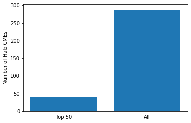

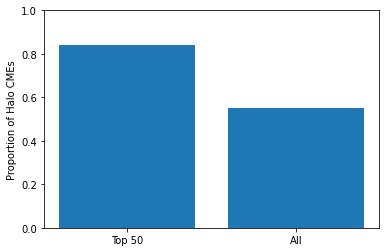

```python
import matplotlib.pyplot as plt

# proportion of Halo CMEs in the top 50 flares
halo_top_50 = top_50[top_50['is_halo']]
halo_top_50_count = len(halo_top_50)
halo_top_50_prop = halo_top_50_count / len(top_50)

# proportion of Halo CMEs in all flares
halo_all = nasa[nasa['is_halo']]
halo_all_count = len(halo_all)
halo_all_prop = halo_all_count / len(df)

labels = ['Top 50', 'All']
counts = [halo_top_50_count, halo_all_count]
proportions = [halo_top_50_prop, halo_all_prop]

fig, ax = plt.subplots()
ax.bar(labels, counts)
ax.set_ylabel('Number of Halo CMEs')

fig, ax = plt.subplots()
ax.bar(labels, proportions)
ax.set_ylabel('Proportion of Halo CMEs')
ax.set_ylim(0, 1)

plt.show()
```